# Spatial visualization of house price at Baltimore

# Lesson Goals

In this lesson we will describe a common type of geovizualization used for area unit data with numeric attributes, namely choropleth maps.

Choropleth maps play a prominent role in spatial data science. The word choropleth stems from the root "choro" meaning "region". As such choropleth maps are appropriate for areal unit data where each observation combines a value of an attribute and a polygon. Choropleth maps derive from an earlier era where cartographers faced technological constraints that precluded the use of unclassed maps where each unique attribute value could be represented by a distinct symbol. Instead, attribute values were grouped into a smaller number of classes with each class being associated with a unique symbol that was in turn applied to all polygons with attribute values falling in the class.

# Prerequests

1. Install the below mentioned libraries

   NB:make sure Jupyter Notebook compatability(this one is Anaconda 3.7X)

```python
import libpysal
import geopandas as gpd
import mapclassify
import pandas as pd
import geopandas as gpd
import libpysal as lp
import matplotlib.pyplot as plt
import rasterio as rio
import numpy as np
import contextily as ctx
import shapely.geometry as geom
%matplotlib inline
```

The example in this notebook use data on Baltimore house sales prices which is a built-in dataset available through libpysal. We use libpysal to obtain the path to the shapefile and then use geopandas to create a geodataframe from the shapefile:

```python
libpysal.examples.explain('baltim')
```

```
baltim
======

Baltimore house sales prices and hedonics, 1978.
----------------------------------------------------------------

* baltim.dbf: attribute data. (k=17)
* baltim.shp: Point shapefile. (n=211)
* baltim.shx: spatial index.
* baltim.tri.k12.kwt: kernel weights using a triangular kernel with 12 nearest neighbors in KWT format.
* baltim_k4.gwt: nearest neighbor weights (4nn) in GWT format.
* baltim_q.gal: queen contiguity weights in GAL format.
* baltimore.geojson: spatial weights in geojson format.

Source: Dubin, Robin A. (1992). Spatial autocorrelation and neighborhood quality. Regional Science and Urban Economics 22(3), 433-452.
```

### Attribute Distribution (a-spatial)

```python
pth = libpysal.examples.get_path('baltim.shp')
gdf = gpd.read_file(pth)
```

```python
gdf.head()
```

|  | STATION | PRICE | NROOM | DWELL | NBATH | PATIO | FIREPL | AC | BMENT | NSTOR | GAR | AGE | CITCOU | LOTSZ | SQFT | X | Y | geometry |
| --- | --- | --- | --- | --- | --- | --- | --- | --- | --- | --- | --- | --- | --- | --- | --- | --- | --- | --- |
| 0 | 1 | 47.0 | 4.0 | 0.0 | 1.0 | 0.0 | 0.0 | 0.0 | 2.0 | 3.0 | 0.0 | 148.0 | 0.0 | 5.70 | 11.25 | 907.0 | 534.0 | POINT (907.000 534.000) |
| 1 | 2 | 113.0 | 7.0 | 1.0 | 2.5 | 1.0 | 1.0 | 1.0 | 2.0 | 2.0 | 2.0 | 9.0 | 1.0 | 279.51 | 28.92 | 922.0 | 574.0 | POINT (922.000 574.000) |
| 2 | 3 | 165.0 | 7.0 | 1.0 | 2.5 | 1.0 | 1.0 | 0.0 | 3.0 | 2.0 | 2.0 | 23.0 | 1.0 | 70.64 | 30.62 | 920.0 | 581.0 | POINT (920.000 581.000) |
| 3 | 4 | 104.3 | 7.0 | 1.0 | 2.5 | 1.0 | 1.0 | 1.0 | 2.0 | 2.0 | 2.0 | 5.0 | 1.0 | 174.63 | 26.12 | 923.0 | 578.0 | POINT (923.000 578.000) |
| 4 | 5 | 62.5 | 7.0 | 1.0 | 1.5 | 1.0 | 1.0 | 0.0 | 2.0 | 2.0 | 0.0 | 19.0 | 1.0 | 107.80 | 22.04 | 918.0 | 574.0 | POINT (918.000 574.000) |

## Data classification

Data classification considers the problem of a partitioning of the attribute values into mutually exclusive and exhaustive groups. The precise manner in which this is done will be a function of the measurement scale of the attribute in question. For quantitative attributes (ordinal, interval, ratio scales) the classes will have an explicit ordering.

```python
import seaborn as sbn
```

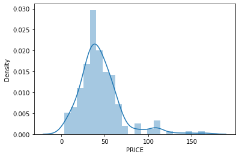

```python
sbn.distplot(gdf['PRICE'])
```

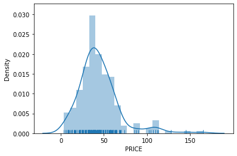

```python
sbn.distplot(gdf['PRICE'], rug=True)
```

## Spatial Distribution - spatial visualization

The distplot combines a histogram with a kernel density. Both reflect a right-skewed distribution, not uncommon for housing rents, or urban income distributions.

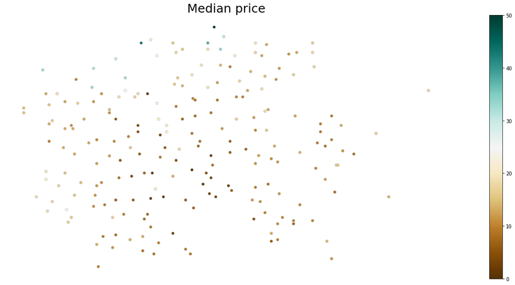

```python
# set the value column that will be visualised
variable = 'PRICE'
# set the range for the choropleth values
vmin, vmax = 0, 50
# create figure and axes for Matplotlib
fig, ax = plt.subplots(1, figsize=(30, 10))
# remove the axis
ax.axis('off')
# add a title and annotation
ax.set_title('Median price', fontdict={'fontsize': '25', 'fontweight' : '3'})

# Create colorbar legend
sm = plt.cm.ScalarMappable(cmap='BrBG', norm=plt.Normalize(vmin=vmin, vmax=vmax))
# empty array for the data range
sm.set_array([]) # or alternatively sm._A = []. Not sure why this step is necessary, but many recommends it
# add the colorbar to the figure
fig.colorbar(sm)
# create map
gdf.plot(column=variable, cmap='BrBG', linewidth=0.8, ax=ax, edgecolor='0.8')
#df.plot(column='median_price', scheme='Quantiles', k=10, figsize=(16, 9))
```

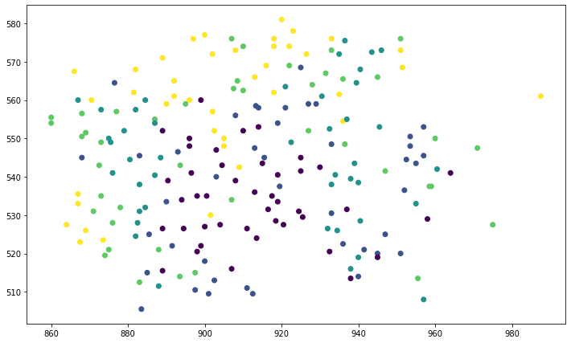

```python
fig, ax = plt.subplots(figsize=(12,10), subplot_kw={'aspect':'equal'})
gdf.plot(column='PRICE', scheme='Quantiles', ax=ax)
```

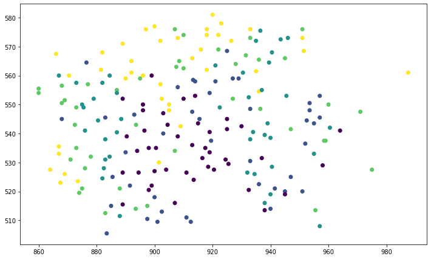

```python
fig, ax = plt.subplots(figsize=(12,10), subplot_kw={'aspect':'equal'})
gdf.plot(column='PRICE', scheme='Quantiles', ax=ax)
```

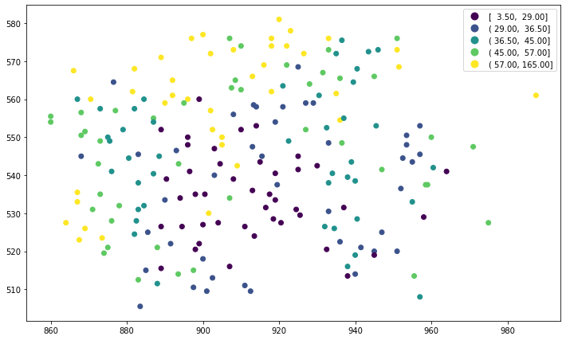

```python
fig, ax = plt.subplots(figsize=(12,10), subplot_kw={'aspect':'equal'})
gdf.plot(column='PRICE', scheme='Quantiles',  legend=True, ax=ax)
```

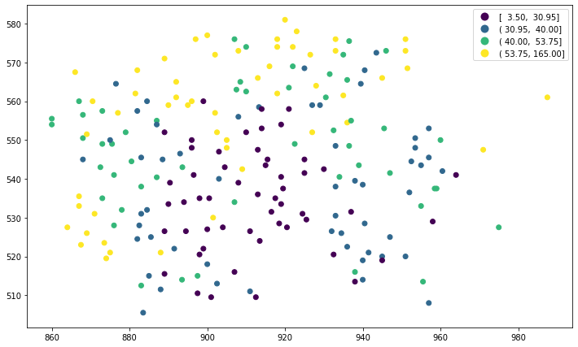

```python
fig, ax = plt.subplots(figsize=(12,10), subplot_kw={'aspect':'equal'})
gdf.plot(column='PRICE', scheme='Quantiles', k=4, legend=True, ax=ax)
```

[figure not shown]

```python
f,ax = plt.subplots(1,3,figsize=(3.16*4,4), subplot_kw=dict(aspect='equal'))
gdf.plot(column='PRICE', ax=ax[0], edgecolor='k',
        scheme="quantiles",  k=4)
ax[0].axis(gdf.total_bounds[np.asarray([0,2,1,3])])
ax[0].set_title("Default")
gdf.plot(column='PRICE', ax=ax[1], edgecolor='k',
        scheme='quantiles', cmap='OrRd', k=4)
ax[1].axis(gdf.total_bounds[np.asarray([0,2,1,3])])
ax[1].set_title("OrRd")
gdf.plot(column='PRICE', ax=ax[2], edgecolor='k',
        scheme='quantiles', cmap='GnBu', k=4)
ax[2].axis(gdf.total_bounds[np.asarray([0,2,1,3])])
ax[2].set_title("BrBg")
ax[0].axis('off')
ax[1].axis('off')
ax[2].axis('off')
plt.show()
```

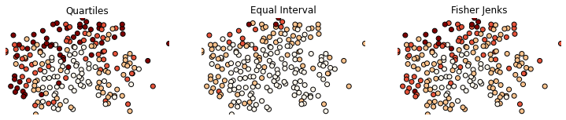

```python
f,ax = plt.subplots(1,3,figsize=(3.16*4,4), subplot_kw=dict(aspect='equal'))
gdf.plot(column='PRICE', ax=ax[0], edgecolor='k',
        scheme="quantiles", cmap='OrRd', k=4)
ax[0].axis(gdf.total_bounds[np.asarray([0,2,1,3])])
ax[0].set_title("Quartiles")
gdf.plot(column='PRICE', ax=ax[1], edgecolor='k',
        scheme='equal_interval', cmap='OrRd', k=4)
ax[1].axis(gdf.total_bounds[np.asarray([0,2,1,3])])
ax[1].set_title("Equal Interval")
gdf.plot(column='PRICE', ax=ax[2], edgecolor='k',
       scheme='fisher_jenks', cmap='OrRd', k=4)
ax[2].axis(gdf.total_bounds[np.asarray([0,2,1,3])])
ax[2].set_title("Fisher Jenks")
ax[0].axis('off')
ax[1].axis('off')
ax[2].axis('off')
plt.show()
```

GeoPandas supports a subset of the map classification schemes that are available in PySAL. The selected ones have a similar function signature that allowed for a simple soft dependency. Since the initial implementation, PySAL has begun a major refactoring, and as part of this the classification scheme have been moved into their own package: mapclassify. We can explore some of the other classifiers within this package:

```python
import mapclassify as mc
```

```python
mc.CLASSIFIERS
```

```
('BoxPlot',
 'EqualInterval',
 'FisherJenks',
 'FisherJenksSampled',
 'HeadTailBreaks',
 'JenksCaspall',
 'JenksCaspallForced',
 'JenksCaspallSampled',
 'MaxP',
 'MaximumBreaks',
 'NaturalBreaks',
 'Quantiles',
 'Percentiles',
 'StdMean',
 'UserDefined')
```

```python
y = gdf['PRICE']
ea5 = mc.EqualInterval(y, k=5)
```

```python
ea5
```

```
EqualInterval

    Interval       Count
------------------------
[  3.50,  35.80] |    81
( 35.80,  68.10] |   111
( 68.10, 100.40] |     9
(100.40, 132.70] |     8
(132.70, 165.00] |     2
```

```python
ea5.yb
```

```
array([1, 3, 4, 3, 1, 2, 3, 1, 1, 4, 1, 1, 1, 1, 1, 0, 0, 0, 1, 1, 1, 0,
       0, 1, 1, 1, 1, 1, 1, 1, 1, 1, 1, 1, 0, 1, 1, 1, 1, 1, 1, 1, 1, 3,
       3, 1, 1, 3, 0, 1, 1, 3, 0, 1, 1, 2, 1, 3, 1, 2, 2, 2, 0, 0, 1, 0,
       1, 0, 1, 2, 0, 0, 0, 0, 1, 0, 1, 0, 1, 0, 1, 0, 0, 0, 0, 1, 1, 0,
       0, 0, 0, 0, 1, 0, 0, 0, 1, 1, 0, 1, 1, 1, 1, 0, 0, 0, 0, 0, 1, 0,
       1, 1, 0, 0, 1, 1, 0, 0, 0, 0, 1, 1, 1, 1, 0, 1, 1, 0, 0, 1, 0, 0,
       1, 0, 0, 0, 0, 0, 0, 0, 0, 0, 0, 0, 1, 1, 1, 1, 1, 0, 0, 0, 1, 1,
       1, 2, 1, 1, 1, 1, 1, 1, 2, 1, 0, 1, 0, 0, 0, 1, 0, 1, 0, 0, 0, 0,
       0, 0, 0, 0, 1, 1, 1, 1, 2, 1, 1, 1, 1, 1, 0, 0, 1, 1, 1, 1, 1, 1,
       1, 1, 1, 1, 1, 1, 1, 1, 1, 1, 0, 0, 0])
```

```python
q5 = mc.Quantiles(y, k=5)
q5
```

```
Quantiles

    Interval       Count
------------------------
[  3.50,  29.00] |    43
( 29.00,  36.50] |    42
( 36.50,  45.00] |    43
( 45.00,  57.00] |    43
( 57.00, 165.00] |    40
```

```python
q5.yb
```

```
array([3, 4, 4, 4, 4, 4, 4, 3, 4, 4, 4, 4, 4, 3, 3, 0, 0, 0, 1, 2, 3, 0,
       0, 3, 4, 3, 3, 3, 2, 3, 2, 2, 2, 2, 1, 2, 3, 3, 3, 2, 3, 1, 2, 4,
       4, 2, 3, 4, 1, 4, 2, 4, 0, 4, 4, 4, 3, 4, 4, 4, 4, 4, 0, 0, 3, 0,
       3, 1, 3, 4, 1, 0, 0, 1, 2, 1, 2, 0, 3, 0, 2, 1, 0, 0, 0, 2, 3, 0,
       0, 0, 1, 1, 4, 1, 0, 0, 2, 3, 1, 3, 3, 4, 2, 1, 1, 1, 0, 1, 3, 1,
       2, 3, 0, 1, 3, 3, 1, 0, 1, 1, 1, 1, 2, 2, 1, 2, 2, 0, 0, 2, 0, 0,
       4, 0, 0, 0, 0, 1, 0, 0, 1, 1, 1, 1, 3, 2, 3, 3, 3, 1, 1, 1, 3, 4,
       4, 4, 4, 2, 3, 4, 3, 3, 4, 3, 0, 2, 1, 0, 1, 2, 1, 2, 0, 0, 0, 0,
       1, 0, 0, 1, 3, 3, 2, 2, 4, 2, 4, 2, 2, 3, 1, 1, 4, 2, 2, 3, 4, 4,
       3, 2, 3, 2, 2, 2, 2, 2, 2, 2, 0, 1, 1])
```

While equal-width bins have the same width, quantiles attempt to have the same number of observations assigned to each of the 𝑘 classes. A close look at the result for the quintiles reveals this is not exact for the price data. The reason for this is that there are substantially less than 𝑛 unique observations:

```python
y.shape
```

```
(211,)
```

```python
np.unique(y).shape
```

```
(140,)
```

## Selecting a classification based on fit

Choropleth mapping can be used for different purposes. The most common is to select a classification that provides a balance between maximizing the differences between observations in each bin, and minimizing the intra-bin heterogeneity.

One such measure is the the absolute deviation around class medians (ADCM). Let's use this to compare all k=5 classifiers:

```python
q5 = mc.Quantiles(y, k=5)
ei5 = mc.EqualInterval(y, k=5)
mb5 = mc.MaximumBreaks(y, k=5)
fj5 = mc.FisherJenks(y, k=5)
fits = [c.adcm for c in [q5, ei5, mb5, fj5]]
fits
```

```
[1306.915, 1514.285, 2609.6149999999993, 1141.615]
```

As expected, Fisher Jenks is the optimal classifer.

## Outlier Detection

Another application of choropleth mapping is to identify either data errors or extreme values. There are a number of classifers that can be used to detect value outliers:

```python
ht = mc.HeadTailBreaks(y)
ht
```

```
HeadTailBreaks

    Interval       Count
------------------------
[  3.50,  44.31] |   123
( 44.31,  63.88] |    63
( 63.88,  91.58] |    15
( 91.58, 119.58] |     7
(119.58, 145.83] |     2
(145.83, 165.00] |     1
```

```python
std = mc.StdMean(y)
std
```

```
StdMean

    Interval       Count
------------------------
(  -inf,  -2.90] |     0
( -2.90,  20.70] |    21
( 20.70,  67.91] |   171
( 67.91,  91.52] |     9
( 91.52, 165.00] |    10
```

## Using mapclassify with GeoPandas

Although only a subset of the PySAL classifiers are directly accessible from within GeoPandas, it is possible to combine external classifiers with GeoPandas:

```python
bp = mc.BoxPlot(y)
bp
```

```
BoxPlot

    Interval       Count
------------------------
(  -inf,  -3.25] |     0
( -3.25,  30.95] |    53
( 30.95,  40.00] |    54
( 40.00,  53.75] |    51
( 53.75,  87.95] |    42
( 87.95, 165.00] |    11
```

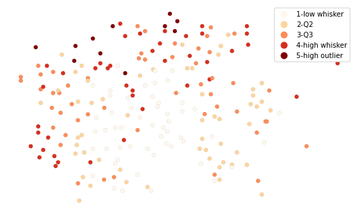

```python
labels = ['0-low outlier', '1-low whisker',
          '2-Q2', '3-Q3', '4-high whisker', '5-high outlier']
bpl = [ labels[b] for b in bp.yb ]

f, ax = plt.subplots(1, figsize=(9, 9))
gdf.assign(cl=bpl).plot(column='cl', categorical=True, \
                                      k=4, cmap='OrRd', linewidth=0.1, ax=ax,\
                                      edgecolor='grey', legend=True)
ax.set_axis_off()
plt.show()
```

# Further reading

1.Spatial Effects and House Price Dynamics in the U.S.A [link](https://sites.tufts.edu/yioannides/files/2015/02/CohenIoannidesThanapisitikul-REVISED-2-17-15.-Fullpdf.pdf).

2.Spatial Fragmentation and the Value of Residential Housing [link](https://pubag.nal.usda.gov/pubag/downloadPDF.xhtml?id=54240&content=PDF).

3.GeoSparkViz: A Scalable Geospatial Data Visualization Framework in the Apache Spark Ecosystem [link](http://www.public.asu.edu/~jiayu2/geospark/publication/geosparkviz-ssdbm-2018.pdf)

## Conclusion

In this lesson you learn spatial data exploration. Specifically:

- how to visualised spatial data using different spatial library.
- how to apply map classification
- how to choose type of map classification.
- how to detect outliner

# Next Step

There is still much room to dig further. For example, you can try same exercise by converting point data into polygon or try to improve the skewness which shows biase.